# Lab 3

STA 206 | Fall 2021

October 11, 2021

## Residual Plots

Analyzing the residuals of a fitted regression model can give us insight about the appropriateness of the model and how well the model fits the data. We can make various plots to have a visual understanding of the fits and conduct model diagnostics.

When using the default R `plot` function, the first argument is for the variable on the x-axis and the second argument is for the variable on the y-axis. `xlab` and `ylab` specify the labels for the x-axis and y-axis, respectively. The `abline` function adds a straight line to an existing plot.

In this lab, we will continue working on the `Copier.txt` data from last week.

```r
## Read in data
copier = read.table("Copier.txt", header=FALSE)

## Fit a simple regression model
fit = lm(V1~V2, data=copier)
summary(fit)
```

```
##
## Call:
## lm(formula = V1 ~ V2, data = copier)
##
## Residuals:
##      Min       1Q   Median       3Q      Max
## -22.7723  -3.7371   0.3334   6.3334  15.4039
##
## Coefficients:
##             Estimate Std. Error t value Pr(>|t|)
## (Intercept)  -0.5802     2.8039  -0.207    0.837
## V2           15.0352     0.4831  31.123   <2e-16 ***
## ---
## Signif. codes:  0 '***' 0.001 '**' 0.01 '*' 0.05 '.' 0.1 ' ' 1
##
## Residual standard error: 8.914 on 43 degrees of freedom
## Multiple R-squared:  0.9575, Adjusted R-squared:  0.9565
## F-statistic: 968.7 on 1 and 43 DF,  p-value: < 2.2e-16
```

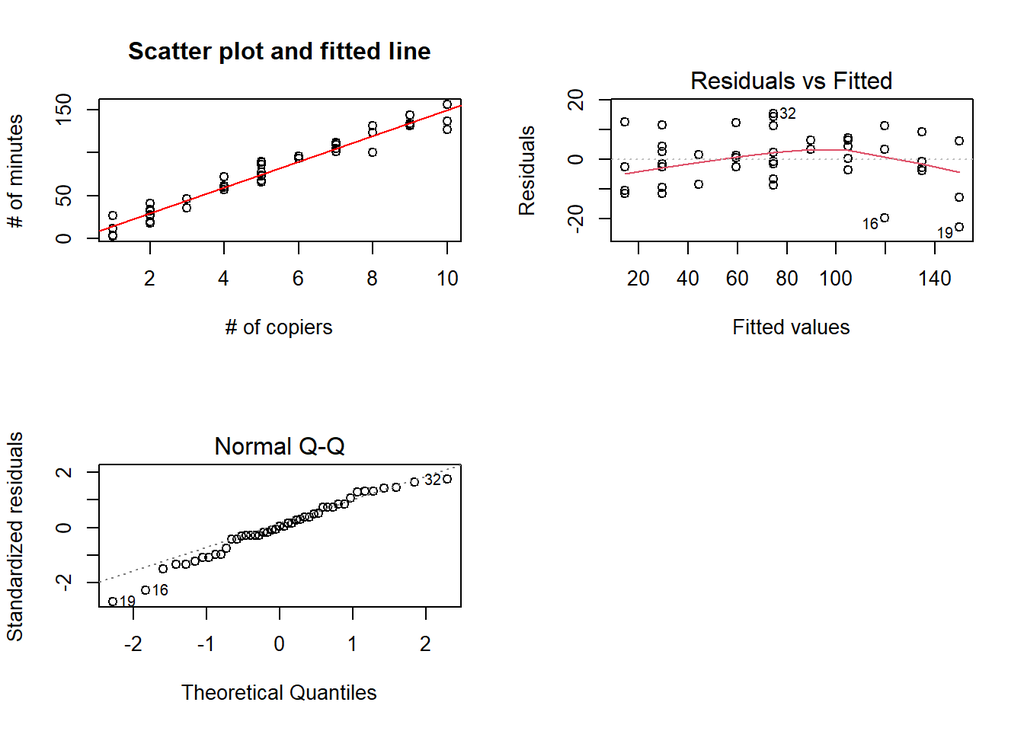

```r
## Plotting
par(mfrow=c(2,2))  #plot 2*2 figures in one panel

plot(copier$V2, copier$V1, xlab='# of copiers', ylab='# of minutes', main='Scatter plot and fitted line')
abline(fit, col='red')  #adding the fitted line (red)

plot(fit, which=1)  # plot the residuals against the fitted value
plot(fit, which=2)  # plot the normal-qq plot of the residuals
```

If the model is adequate, the “residual vs fitted” plot should show no obvious pattern. Moreover, the spread of the residuals should be roughly the same across the horizontal axis. If the errors are normally distributed, the points in the Normal Q-Q plot should roughly fall on a straight line.

We can also just use the default plotting function of lm:

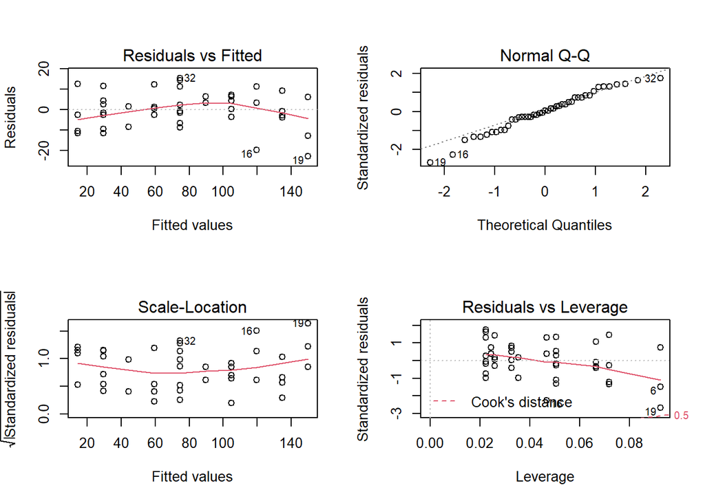

```r
par(mfrow=c(2,2))
plot(fit)
```

```r
par(mfrow=c(1,1))
```

## Transformations

Sometimes when some basic assumptions of the model are not satisfied, we can use transformation as a remedy. We can either transform the response variable Y, or the predictor variable X.

- When the error terms are reasonably normally distributed with approximately constant variance, we apply transformation on the predictor variable X to linearize a non-linear relationship, since transformation of Y may change the distribution of error terms. Commonly used transformations include log, square root, reciprocal, exponential, etc.
- When there appears to be unequal variance or/and non-normality problems, transformation should be done on the response variable Y. Applying transformation on Y can change the distributions of error terms. Commonly used transformations include log, square root, reciprocal, etc. A transformation of the response variable from the family of power transformations may be chosen automatically by the *Box-Cox* procedure.
- We may transform X and Y simultaneously if necessary.

Let’s consider the following data in the file `trans1.txt`.

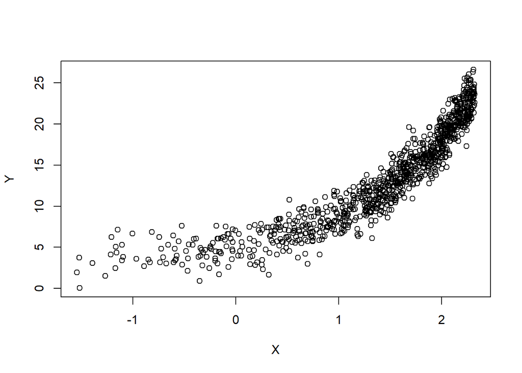

```r
d1 = read.table("trans1.txt", header = TRUE)
plot(d1)
```

The scatterplot does not suggest that a linear relation between X and Y is adequate here. If we fit a simple regression model to the data, the diagnostic plots will display a warning sign: there is a nonlinear trend in the residual vs. fitted value plot.

```r
fit1.1 = lm(Y~X, data = d1)
summary(fit1.1)
```

```
##
## Call:
## lm(formula = Y ~ X, data = d1)
##
## Residuals:
##    Min     1Q Median     3Q    Max
## -7.107 -1.952 -0.296  1.617 10.281
##
## Coefficients:
##             Estimate Std. Error t value Pr(>|t|)
## (Intercept)   4.4327     0.1691   26.22   <2e-16 ***
## X             6.6134     0.1041   63.50   <2e-16 ***
## ---
## Signif. codes:  0 '***' 0.001 '**' 0.01 '*' 0.05 '.' 0.1 ' ' 1
##
## Residual standard error: 2.665 on 998 degrees of freedom
## Multiple R-squared:  0.8016, Adjusted R-squared:  0.8014
## F-statistic:  4033 on 1 and 998 DF,  p-value: < 2.2e-16
```

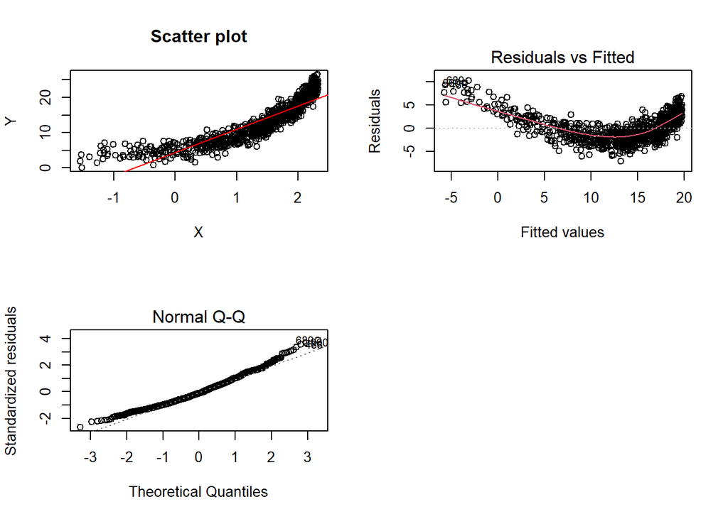

```r
par(mfrow = c(2,2))
plot(d1, main='Scatter plot')
abline(fit1.1, col='red')
plot(fit1.1, which=1)
plot(fit1.1, which=2)

par(mfrow = c(1,1))
```

In this case, we see that the linearity assumption is not satisfied here and we can transform the X variable in this case. It is clear from the scatterplot that there is a quadratic trend. So, we may want to square the X values and then fit a linear regression.

```r
fit1.2 <- lm(Y~I(X^2), data = d1)
summary(fit1.2)
```

```
##
## Call:
## lm(formula = Y ~ I(X^2), data = d1)
##
## Residuals:
##      Min       1Q   Median       3Q      Max
## -12.5695  -1.0225   0.0123   1.2048   5.2051
##
## Coefficients:
##             Estimate Std. Error t value Pr(>|t|)
## (Intercept)  4.89251    0.10710   45.68   <2e-16 ***
## I(X^2)       3.35687    0.03417   98.23   <2e-16 ***
## ---
## Signif. codes:  0 '***' 0.001 '**' 0.01 '*' 0.05 '.' 0.1 ' ' 1
##
## Residual standard error: 1.832 on 998 degrees of freedom
## Multiple R-squared:  0.9063, Adjusted R-squared:  0.9062
## F-statistic:  9648 on 1 and 998 DF,  p-value: < 2.2e-16
```

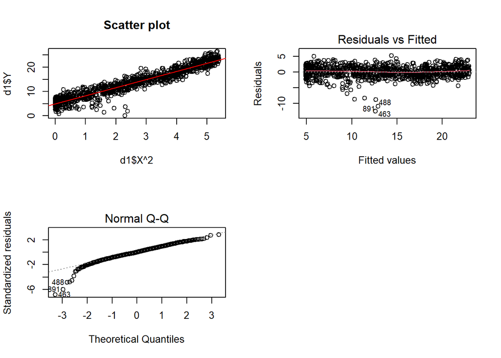

```r
par(mfrow = c(2,2))
plot(d1$X^2, d1$Y, main='Scatter plot')
abline(fit1.2, col='red')
plot(fit1.2, which=1)
plot(fit1.2, which=2)
par(mfrow = c(1,1))
```

Now, we see that on the transformed X, the linear regression is suitable.

**Exercise**: For the data in `trans2.txt`, find the suitable transformation for X and produce the appropriate plots to support your claim.

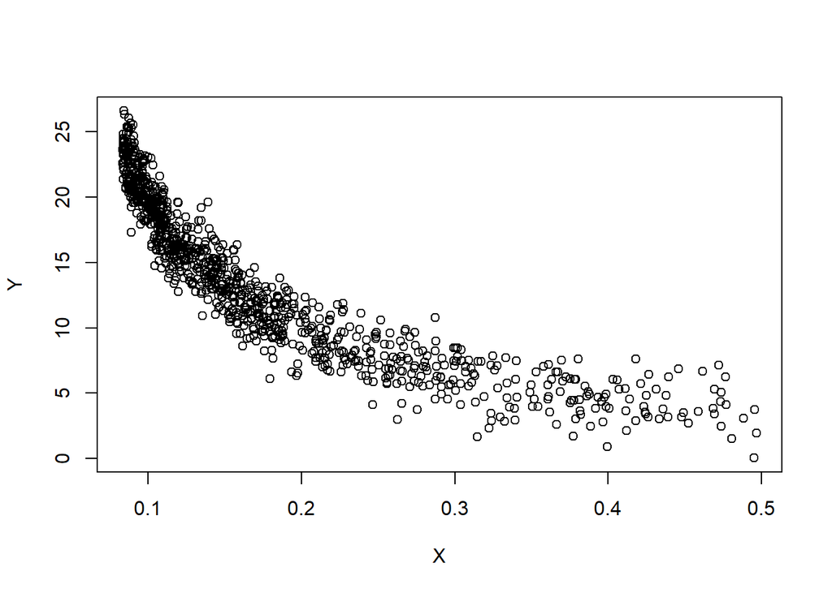

```r
d2 = read.table("trans2.txt", header = TRUE)
plot(d2)
```

```r
####Fill up the details####
# fit2.2 <- lm(Y~I(1/X), data=d2)
# plot(1/d2$X, d2$Y)
# abline(fit2.2)
```

In certain cases, we see from the residual plot that the variance of the residuals are not constant. The QQ plot also shows deviations from Normality.

```r
d4 = read.table("trans4.txt", header = TRUE)

fit4.1 = lm(Y ~ X, data = d4)
summary(fit4.1)
```

```
##
## Call:
## lm(formula = Y ~ X, data = d4)
##
## Residuals:
##    Min     1Q Median     3Q    Max
## -10723  -6050  -1936   2150 365566
##
## Coefficients:
##             Estimate Std. Error t value Pr(>|t|)
## (Intercept)  -5556.7     1207.9  -4.600 4.77e-06 ***
## X             1771.8      209.4   8.462  < 2e-16 ***
## ---
## Signif. codes:  0 '***' 0.001 '**' 0.01 '*' 0.05 '.' 0.1 ' ' 1
##
## Residual standard error: 19090 on 998 degrees of freedom
## Multiple R-squared:  0.06694,    Adjusted R-squared:  0.06601
## F-statistic:  71.6 on 1 and 998 DF,  p-value: < 2.2e-16
```

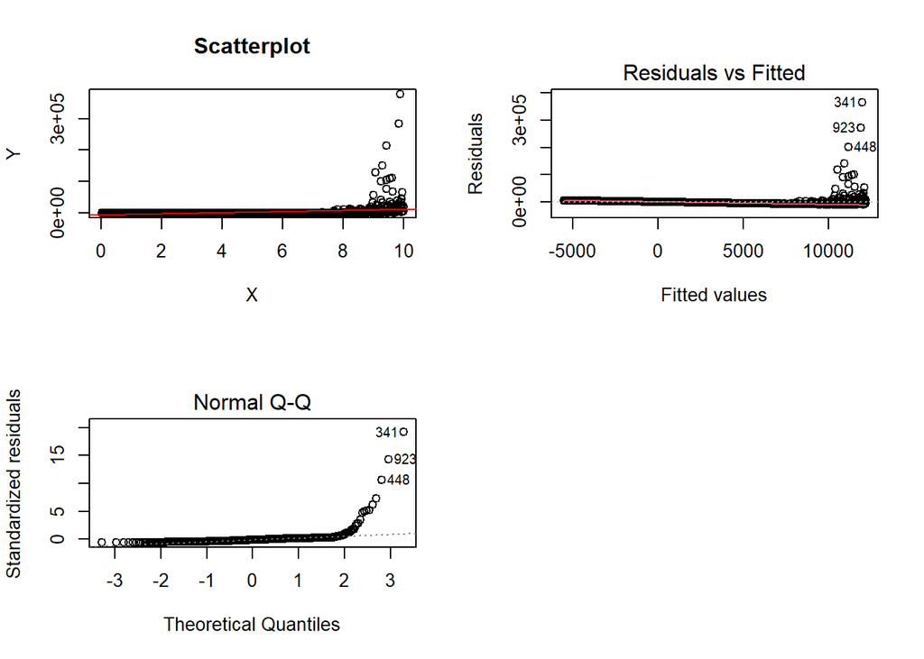

```r
par(mfrow = c(2,2))

plot(d4, main = "Scatterplot")
abline(fit4.1, col='red')
plot(fit4.1, which=1)
plot(fit4.1, which=2)
par(mfrow = c(1,1))
```

Then, we transform Y. Usually, we can use Box-Cox procedure to find an appropriate transformation. Box-Cox transformation is in MASS (math) library of R.

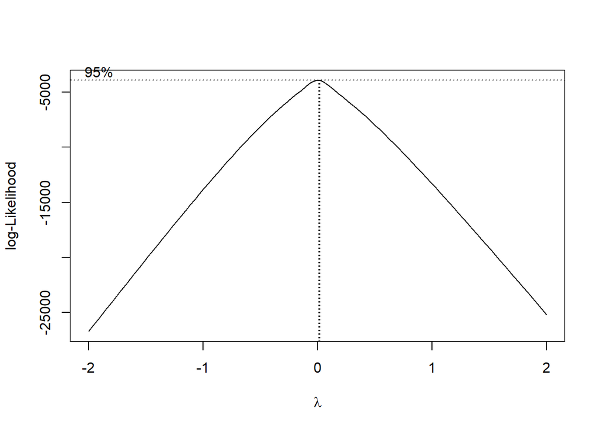

```r
library(MASS)
boxcox(lm(Y~X, data = d4))
```

The vertical axis of the plot is the loglikelihood based on different transformations on Y. The horizontal axis is the value of the power of Y. The transformation is $Y_{new} = Y^{\lambda}$. We usually round up the value to make it easily interpretable. For example, when the optimal $\lambda$ is around 0.45, we make it 0.5. When optimal $\lambda$ is 0, we use a log-transformation.

We can see the log-likelihood is largest when $\lambda$ is around 0, which means the slog transformation is appropriate.

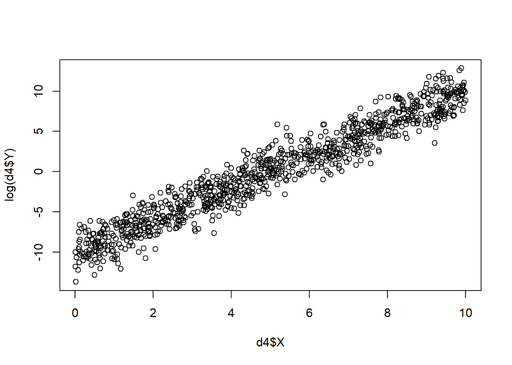

```r
plot(d4$X, log(d4$Y))
```

```r
fit4.2 = lm(log(Y) ~ X, data=d4)

summary(fit4.1)
```

```
##
## Call:
## lm(formula = Y ~ X, data = d4)
##
## Residuals:
##    Min     1Q Median     3Q    Max
## -10723  -6050  -1936   2150 365566
##
## Coefficients:
##             Estimate Std. Error t value Pr(>|t|)
## (Intercept)  -5556.7     1207.9  -4.600 4.77e-06 ***
## X             1771.8      209.4   8.462  < 2e-16 ***
## ---
## Signif. codes:  0 '***' 0.001 '**' 0.01 '*' 0.05 '.' 0.1 ' ' 1
##
## Residual standard error: 19090 on 998 degrees of freedom
## Multiple R-squared:  0.06694,    Adjusted R-squared:  0.06601
## F-statistic:  71.6 on 1 and 998 DF,  p-value: < 2.2e-16
```

```r
summary(fit4.2)
```

```
##
## Call:
## lm(formula = log(Y) ~ X, data = d4)
##
## Residuals:
##     Min      1Q  Median      3Q     Max
## -4.8565 -1.1004 -0.0235  1.1090  5.4955
##
## Coefficients:
##              Estimate Std. Error t value Pr(>|t|)
## (Intercept) -10.00974    0.09815  -102.0   <2e-16 ***
## X             2.00318    0.01702   117.7   <2e-16 ***
## ---
## Signif. codes:  0 '***' 0.001 '**' 0.01 '*' 0.05 '.' 0.1 ' ' 1
##
## Residual standard error: 1.551 on 998 degrees of freedom
## Multiple R-squared:  0.9328, Adjusted R-squared:  0.9328
## F-statistic: 1.386e+04 on 1 and 998 DF,  p-value: < 2.2e-16
```

The multiple R-squared increased from 0.066 to 0.933.

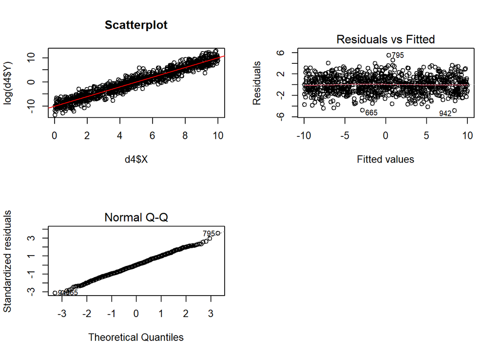

```r
par(mfrow = c(2,2))
plot(d4$X, log(d4$Y), main = "Scatterplot")
abline(fit4.2, col='red')
plot(fit4.2, which=1)
plot(fit4.2, which=2)
par(mfrow = c(1,1))
```

The diagnostic plots suggest that conformity to assumptions has been improved.

**Exercise**: Try Box-Cox transformation on `trans5.txt` and produce the necessary plots to support the transformation.

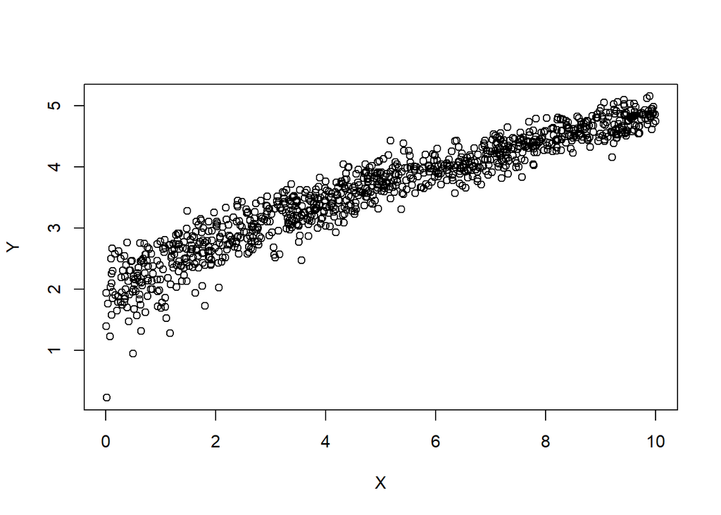

```r
d5 = read.table("trans5.txt", header = TRUE)
plot(d5)
```

```r
###Fill up the rest###
# boxcox(lm(Y~X, data = d5))
```

## Matrix in R

A matrix is a 2 dimensional array of numbers. We will first look into some basic matrix operations.

```r
##Create matrix
mat1 = matrix(1:12, nrow = 3, ncol = 4)
mat1
```

```
##      [,1] [,2] [,3] [,4]
## [1,]    1    4    7   10
## [2,]    2    5    8   11
## [3,]    3    6    9   12
```

```r
##Accessing the (3,2)th element of mat1
mat1[3,2]
```

```
## [1] 6
```

```r
##Accessing the 3rd row of mat1
mat1[3, ]
```

```
## [1]  3  6  9 12
```

```r
##Accessing the 2nd column of mat1
mat1[ ,2]
```

```
## [1] 4 5 6
```

Note that in R, matrix enters the elements columnwise by default. To know more, go to matrix help (?matrix).

Now we will focus on matrix operations in linear regression. We have obtained the following data:

```r
#case Y  X
#1    42 7
#2    33 4
#3    75 16
#4    28 3
#5    91 21
#6    55 8
```

Let’s start by first inputting the data into R, and then renaming the columns so that we don’t get the variables confused:

```r
dt = matrix(c(42, 33, 75, 28, 91, 55, 7, 4, 16, 3, 21, 8), 6, 2)
colnames(dt) = c('Y', 'X')
```

We have learned how to draw the scatter plot using the function `plot` to see what our data look like. In fact, we do have other ways of seeing how the variables are related (they are widely used in multiple linear regression):

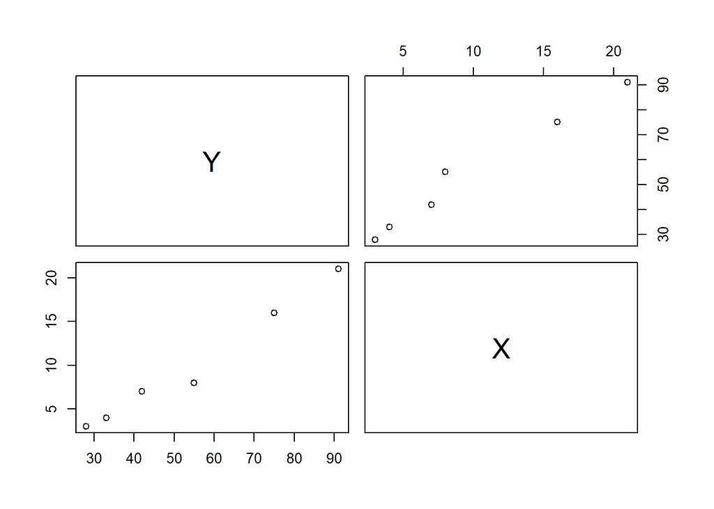

```r
pairs(dt) ## pairwise scatter plots
```

```r
cor(dt) ## pairwise correlation matrix
```

```
##           Y         X
## Y 1.0000000 0.9889386
## X 0.9889386 1.0000000
```

Now that we have an idea about what our data look like, let’s perform simple linear regression using matrix algebra in R. The first step is to specify the response vector $Y$ and the design matrix $\mathbf{X}$ (notice here the dimensions of $\mathbf{X}$ are $n \times 2$, where 2 is the number of regression coefficients in our model (including intercept)).

```r
Y = dt[,1] # create response variable
n = length(Y) # number of obeservations

X = cbind(rep(1,n), dt[,2]) #design matrix
X
```

```
##      [,1] [,2]
## [1,]    1    7
## [2,]    1    4
## [3,]    1   16
## [4,]    1    3
## [5,]    1   21
## [6,]    1    8
```

Recall that the last line of code is saying “make a matrix that puts together a column of ones, along with columns 2 of our data.” Similarly, we can use the `model.matrix` function:

```r
X = model.matrix( dt[,1] ~ dt[,2] )
X
```

```
##   (Intercept) dt[, 2]
## 1           1       7
## 2           1       4
## 3           1      16
## 4           1       3
## 5           1      21
## 6           1       8
## attr(,"assign")
## [1] 0 1
```

`model.matrix` is also useful for generating design matrices for higher-order terms e.g.

```r
model.matrix( dt[,1] ~ dt[,2]+I(dt[,2]^2) )
```

```
##   (Intercept) dt[, 2] I(dt[, 2]^2)
## 1           1       7           49
## 2           1       4           16
## 3           1      16          256
## 4           1       3            9
## 5           1      21          441
## 6           1       8           64
## attr(,"assign")
## [1] 0 1 2
```

Now we have everything we need to find $\hat{\beta}$. We know that
$$\hat{\beta} = (X'X)^{-1}X'Y$$

Remember that $\hat{\beta}$ is now a 2 x 1 vector.

```r
#solve t(X) %*% X %*% beta = t(X) %*% y, for beta
beta.hat = solve(t(X) %*% X, t(X) %*% Y)
beta.hat
```

```
##                  [,1]
## (Intercept) 20.236102
## dt[, 2]      3.433617
```

Let’s check that it gives the same solution as the `lm` function.

```r
lm(Y~X, data=as.data.frame(dt))
```

```
##
## Call:
## lm(formula = Y ~ X, data = as.data.frame(dt))
##
## Coefficients:
## (Intercept)            X
##      20.236        3.434
```

## Notes on data frames

`data.frame` is perhaps the most commonly used data structure in data modeling in R. A data frame is a matrix-like structure whose columns may be of differing types (numeric, logical, factor and character and so on).

We can create `data.frame` by reading files, or by converting matrices or lists.

```r
# d5 <- read.table("trans5.txt", header = TRUE)
class(d5) # data.frame
```

```
## [1] "data.frame"
```

```r
dt <- cbind(dt, 1:6)
class(dt) # matrix
```

```
## [1] "matrix" "array"
```

```r
dt <- as.data.frame(dt)
class(dt)
```

```
## [1] "data.frame"
```

```r
colnames(dt)[3]<- 'Z'
```

### Subsetting Data

We have several ways to select columns (variables)

```r
dt[c('X','Z')]
```

```
##    X Z
## 1  7 1
## 2  4 2
## 3 16 3
## 4  3 4
## 5 21 5
## 6  8 6
```

```r
dt[2:3]
```

```
##    X Z
## 1  7 1
## 2  4 2
## 3 16 3
## 4  3 4
## 5 21 5
## 6  8 6
```

```r
dt[colnames(dt) %in% c("X", "Z")]
```

```
##    X Z
## 1  7 1
## 2  4 2
## 3 16 3
## 4  3 4
## 5 21 5
## 6  8 6
```

```r
dt[c(-1)]
```

```
##    X Z
## 1  7 1
## 2  4 2
## 3 16 3
## 4  3 4
## 5 21 5
## 6  8 6
```

When taking a single variable, notice the following difference

```r
# Returns a data.frame
dt[2]
```

```
##    X
## 1  7
## 2  4
## 3 16
## 4  3
## 5 21
## 6  8
```

```r
dt['X']
```

```
##    X
## 1  7
## 2  4
## 3 16
## 4  3
## 5 21
## 6  8
```

```r
dt['X'][1] # the first column of dt['X']
```

```
##    X
## 1  7
## 2  4
## 3 16
## 4  3
## 5 21
## 6  8
```

```r
dt['X'][1,] # the first row of dt['X']
```

```
## [1] 7
```

```r
# Returns a vector
dt[,2]
```

```
## [1]  7  4 16  3 21  8
```

```r
dt[['X']]
```

```
## [1]  7  4 16  3 21  8
```

```r
dt$X
```

```
## [1]  7  4 16  3 21  8
```

```r
dt$X[1] # the first element of dt$X
```

```
## [1] 7
```

```r
#dt$X[1,] # raises error, dt$X is a vector
```

We also have many ways to select rows (observations).

```r
dt[1:5,] # subset by index
```

```
##    Y  X Z
## 1 42  7 1
## 2 33  4 2
## 3 75 16 3
## 4 28  3 4
## 5 91 21 5
```

```r
dt[dt$Z>3, c('Y','X')] # subset by conditions
```

```
##    Y  X
## 4 28  3
## 5 91 21
## 6 55  8
```

```r
dt[sample(1:nrow(dt), 3),] # takes a random sample
```

```
##    Y  X Z
## 6 55  8 6
## 5 91 21 5
## 4 28  3 4
```